# Statistical machine learning, Lab 3

# Automatic selection of predictors for linear models

The aim of this lab is to learn about classical ways of selecting the number of predictors for a linear model.

## R packages we use in the lab

We are going to use the command `regsubsets()` from `leaps` package for fitting choosing best linear models for each number of predictors. We’ll continue to use `tidymodels` and `tidyverse` packages.

## Exercise 1

Add dummy variables for factor levels to the dataset `ISLR::Credit`, remove the `ID` column and divide it into training and testing part so that training data contains 300 observations. Use the command `initial_split()` for that. The command `training(splitted_data)` extracts the training data from the result and `testing(splitted_data)` extracts test set. Before splitting data, use the command `set.seed(1007)` so that we all get the same results if we use the same version of R.

```r
initial_transformation=recipe(Balance~.,data=ISLR::Credit)|>step_dummy(all_nominal_predictors())|>step_rm(ID)
Credit_transf=initial_transformation |> prep(ISLR::Credit)|>bake(new_data=NULL)
set.seed(1007)
split=initial_split(Credit_transf)
train_df=training(split)
test_df=testing(split)
```

## Exercise 2

Use the command `leaps::regsubsets()` to find the best models for each subset size. In order to look at all model sizes, the parameter `nvmax` should be set to high enough value. To choose the overall best model, we should fix a measure for comparing models with different number of parameters. Which model is the best when we use `Cp`,`BIC` or adjusted $R^2$? Which model is best if we use `AIC` for selection criterion?

*Solution* There are different ways to see how the resulting models look like for each number of different predictors. One possibility is to use plot command (do you understand what you see on the picture?). Alternative and very useful way to see results is to use `tidy()` command, which produces information about which variables were used in the best model for each number of parameters and also different measures of performance for each model

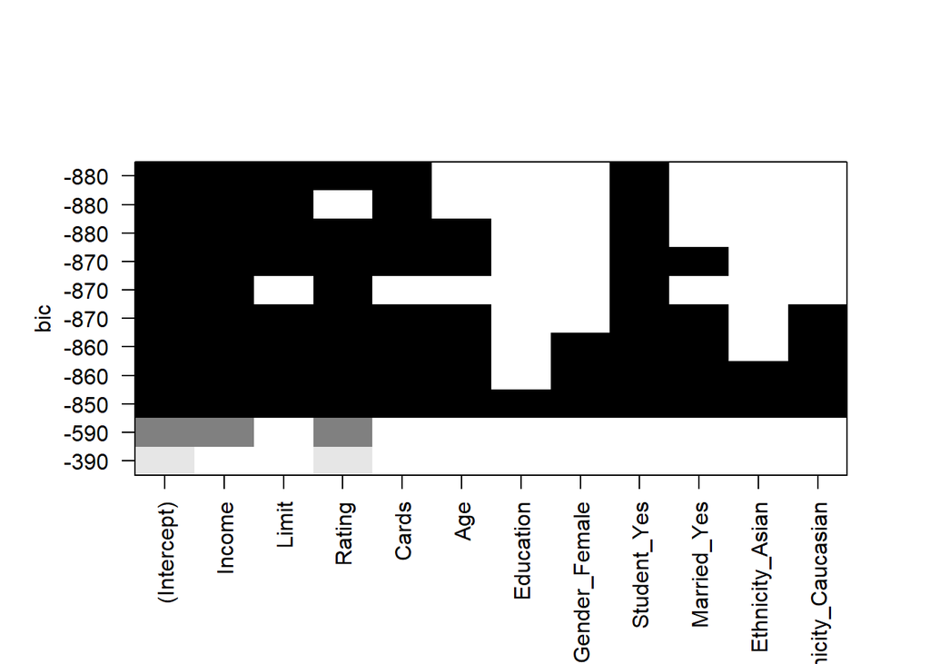

```r
models=leaps::regsubsets(Balance~.,data=train_df,nvmax=11)
plot(models, scale="bic") #scale should show which measure to use to order models
```

```r
models_info=tidy(models)
models_info
```

| (Intercept) | Income | Limit | Rating | Cards | Age | Education | Gender_Female | Student_Yes | Married_Yes | Ethnicity_Asian | Ethnicity_Caucasian | r.squared | adj.r.squared | BIC | mallows_cp |
| --- | --- | --- | --- | --- | --- | --- | --- | --- | --- | --- | --- | --- | --- | --- | --- |
| TRUE | FALSE | FALSE | TRUE | FALSE | FALSE | FALSE | FALSE | FALSE | FALSE | FALSE | FALSE | 0.7354059 | 0.7345180 | -387.4599 | 1337.495736 |
| TRUE | TRUE | FALSE | TRUE | FALSE | FALSE | FALSE | FALSE | FALSE | FALSE | FALSE | FALSE | 0.8688001 | 0.8679166 | -592.1987 | 515.974222 |
| TRUE | TRUE | FALSE | TRUE | FALSE | FALSE | FALSE | FALSE | TRUE | FALSE | FALSE | FALSE | 0.9490632 | 0.9485469 | -870.3357 | 22.463041 |
| TRUE | TRUE | TRUE | FALSE | TRUE | FALSE | FALSE | FALSE | TRUE | FALSE | FALSE | FALSE | 0.9513563 | 0.9506968 | -878.4513 | 10.306008 |
| TRUE | TRUE | TRUE | TRUE | TRUE | FALSE | FALSE | FALSE | TRUE | FALSE | FALSE | FALSE | 0.9524062 | 0.9515967 | -879.2929 | 5.824918 |
| TRUE | TRUE | TRUE | TRUE | TRUE | TRUE | FALSE | FALSE | TRUE | FALSE | FALSE | FALSE | 0.9529199 | 0.9519558 | -876.8452 | 4.653072 |
| TRUE | TRUE | TRUE | TRUE | TRUE | TRUE | FALSE | FALSE | TRUE | TRUE | FALSE | FALSE | 0.9531321 | 0.9520085 | -872.4962 | 5.343417 |
| TRUE | TRUE | TRUE | TRUE | TRUE | TRUE | FALSE | FALSE | TRUE | TRUE | FALSE | TRUE | 0.9532485 | 0.9519632 | -867.5386 | 6.624687 |
| TRUE | TRUE | TRUE | TRUE | TRUE | TRUE | FALSE | TRUE | TRUE | TRUE | FALSE | TRUE | 0.9533317 | 0.9518834 | -862.3692 | 8.111002 |
| TRUE | TRUE | TRUE | TRUE | TRUE | TRUE | FALSE | TRUE | TRUE | TRUE | TRUE | TRUE | 0.9533451 | 0.9517307 | -856.7514 | 10.028417 |

[output cut: 1 more lines]

```r
models_info|>mutate(nvars=row_number(),best_adj_r2=rank(-adj.r.squared),best_bic=rank(BIC),best_cp=rank(mallows_cp))|>select(nvars,starts_with("best"))
```

| nvars | best_adj_r2 | best_bic | best_cp |
| --- | --- | --- | --- |
| 1 | 11 | 11 | 11 |
| 2 | 10 | 10 | 10 |
| 3 | 9 | 5 | 9 |
| 4 | 8 | 2 | 7 |
| 5 | 6 | 1 | 3 |
| 6 | 3 | 3 | 1 |
| 7 | 1 | 4 | 2 |
| 8 | 2 | 6 | 4 |
| 9 | 4 | 7 | 5 |
| 10 | 5 | 8 | 6 |

[output cut: 1 more lines]

According `Cp` we would use model with 6 predictors, by Adjusted $R^2$ we would choose the model with 7 predictors; according to `BIC` the model with 5 predictors should be chosen. As `Cp` and `AIC` should give (according to our textbook) the same models if `AIC` is computed by assuming normal distribution with constant variance, the best model according to AIC should be also model with 6 predictors. We also can compute AIC easily from `BIC`:

```r
n=nrow(train_df)
p=1:nrow(models_info)
AIC=models_info$BIC-(log(n)-2)*p
rank(AIC)
```

```
##  [1] 11 10  9  7  3  1  2  4  5  6  8
```

We see, that the ranking of models by AIC is exactly the same as by `Cp`.

## Exercise 3

Check which of the models actually work best for the concrete test set.

*Solution* We should fit 11 different models with predictors shown in the output of `regsubset()` command. It is completely OK to do this manually if it seems too difficult to write corresponding code, but by using some knowledge about how R works, it is possible to automate this task. For this, we can take out the part of `models_info` data frame which describes which variables each model uses and we can put this knowledge into recipe so that only needed variables are used for each model.

```r
predictor_info=select(models_info,where(is_logical))|>select(-'(Intercept)') #information about which variables are used
predictors=colnames(predictor_info) #vector of variable names
rec_all=recipe(Balance~.,data=train_df) #we can start by recipe which indicates only the output variable
wf_base=workflow()|>add_model(linear_reg()) #all models we fit are linear models; only recipes selecting variables are going to be different
results=rep(NA,length(predictors))
for(i in 1:length(results)){
  #form a vector which contains only names of variables we use in the i-th model
  pred_i=predictors[predictor_info|>slice(i)|>unlist()] #if we use a vector of TRUE/FALSE values as an index, we get only those elements, which correspond to TRUE
  rec_i=rec_all|>step_select(all_of(c("Balance",pred_i))) #modify the starting recipe so that only correct variables are selected
  results[i]=wf_base|>add_recipe(rec_i)|>last_fit(split=split)|>collect_metrics()|>filter(.metric=="rmse")|>pull(.estimate)
}
results
```

```
##  [1] 227.47749 157.15767 104.86465  96.72660  97.65658  97.02706  97.63781
##  [8]  98.28444  98.04364  97.74588  97.63067
```

According to the results the best one for predicting values of Balance for test set is the model with 4 predictors

## Exercise 4

Best subset selection is not always possible because it may be too time consuming. A possibility to to use stepwise selection procedures which try to add/remove one variable at a time to improve the final selection measure. It can be done in forward, backward or mixed directions. Use `stats::step()` to find best models corresponding to those approaches (for mixed search, try starting from the simplest model and also starting from the full model) according to BIC criterion (use `k=log(n)`, where `n` is the number of observations in the training set. Do all approaches give the same final model? Repeat the exercise by selecting models according to AIC. Hint: fit a full model with `lm` command and when starting from a simple model, indicate the full model by `scope=formula(full_model)`.

*Solution* When we want to start from simple models, the first argument of the step function should be a model with only constant predictor and the complete model formula should be given with `scope=` parameter; if we want to work backwards, the first model should be the complete model.

```r
k=log(nrow(train_df))
full_model=lm(Balance~.,data=train_df)
m_forward=stats::step(object=lm(Balance~1,data=train_df),scope=list(lower=~1,upper=formula(full_model)),direction="forward",k=k,trace=0)
m_backward=stats::step(object=full_model,direction="backward",k=k,trace=0)
m_both_fwd=stats::step(object=lm(Balance~1,data=train_df),scope=list(lower=~1,upper=formula(full_model)),direction="both",k=k,trace=0)
m_both_backwd=stats::step(object=full_model,direction="both",k=k,trace=0)
m_forward
```

```
##
## Call:
## lm(formula = Balance ~ Rating + Income + Student_Yes + Limit +
##     Cards, data = train_df)
##
## Coefficients:
## (Intercept)       Rating       Income  Student_Yes        Limit        Cards
##   -532.0747       1.4530      -7.9114     432.8469       0.1688      17.1092
```

```r
m_backward
```

```
##
## Call:
## lm(formula = Balance ~ Income + Limit + Rating + Cards + Student_Yes,
##     data = train_df)
##
## Coefficients:
## (Intercept)       Income        Limit       Rating        Cards  Student_Yes
##   -532.0747      -7.9114       0.1688       1.4530      17.1092     432.8469
```

```r
m_both_fwd
```

```
##
## Call:
## lm(formula = Balance ~ Rating + Income + Student_Yes + Limit +
##     Cards, data = train_df)
##
## Coefficients:
## (Intercept)       Rating       Income  Student_Yes        Limit        Cards
##   -532.0747       1.4530      -7.9114     432.8469       0.1688      17.1092
```

```r
m_both_backwd
```

```
##
## Call:
## lm(formula = Balance ~ Income + Limit + Rating + Cards + Student_Yes,
##     data = train_df)
##
## Coefficients:
## (Intercept)       Income        Limit       Rating        Cards  Student_Yes
##   -532.0747      -7.9114       0.1688       1.4530      17.1092     432.8469
```